# EUR/USD GBP/USD

Simona Mikovčíková

2025-04-23

# 1 1. Výber a spracovanie finančných časových radov

## 1.1 Výber údajov

Pre analýzu boli zvolené dva finančné časové rady: - **EUR/USD** – výmenný kurz eura voči americkému doláru - **GBP/USD** – výmenný kurz britskej libry voči americkému doláru

Údaje boli získané vo forme denného kurzového vývoja za obdobie **od 4. januára 2021 do 31. decembra 2024** zo stránky https://fx.sauder.ubc.ca/fxdata.php.

```r
library(readxl)
library(xts)
library(astsa)#acf2
library(forecast)#Arima
library(tseries)#jarque.bera.test
library(FinTS)#ArchTest
library(rugarch) #GARCH modely
```

```r
# Načítanie dát z excelu
eurusd <- read_excel("eurusd.xlsx")
gbpusd <- read_excel("gbpusd.xlsx")

# Úprava dát
eurusd$Date  <- as.Date(eurusd$Date)
eurusd$`EUR/USD` <- as.numeric(eurusd$`EUR/USD`)
gbpusd$Date  <- as.Date(gbpusd$Date)
gbpusd$`GBP/USD`<- as.numeric(gbpusd$`GBP/USD`)

# Vytvorenie xts objektov a premenných
eur_xts <- xts(eurusd$`EUR/USD`, order.by = eurusd$Date)
colnames(eur_xts) <- "EURUSD"

gbp_xts <- xts(gbpusd$`GBP/USD`, order.by = gbpusd$Date)
colnames(gbp_xts) <- "GBPUSD"

# Spojenie oboch kurzov do jedného objektu
kurzy <- merge(eur_xts, gbp_xts)

# Výpočet prirodzených logaritmov kurzov
logkurzy <- log(kurzy)
```

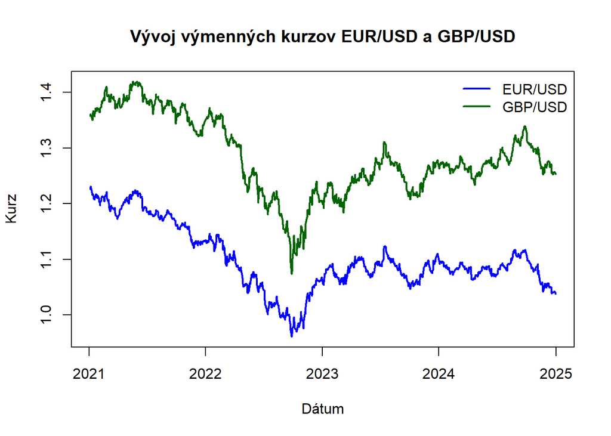

```r
# Grafické znázornenie priebehu výmenných kurzov
plot(index(kurzy), kurzy$EURUSD, type = "l", col = "blue", lwd = 2,
     main = "Vývoj výmenných kurzov EUR/USD a GBP/USD",
     xlab = "Dátum", ylab = "Kurz",
     ylim = range(kurzy, na.rm = TRUE))

lines(index(kurzy), kurzy$GBPUSD, col = "darkgreen", lwd = 2)

legend("topright", legend = c("EUR/USD", "GBP/USD"),
       col = c("blue", "darkgreen"), lwd = 2, bty = "n")
```

Graf zobrazuje vývoj výmenných kurzov **EUR/USD** (modrá čiara) a **GBP/USD** (zelená čiara) od roku 2021 do konca roku 2024. Vidíme, že oba kurzy mali podobný vývoj.

# 2 2. ACF a PACF – testovanie stacionarity

Pre časové rady logaritmov kurzov EUR/USD a GBP/USD boli vytvorené grafy ACF a PACF.

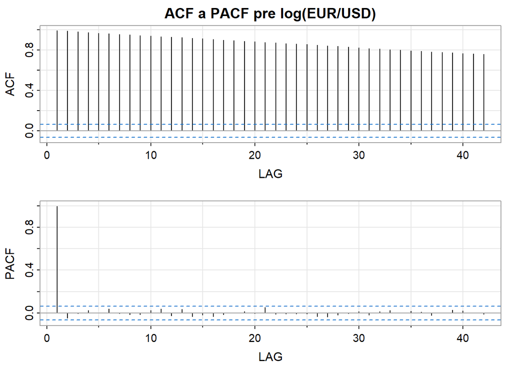

```
##      [,1]  [,2]  [,3] [,4] [,5] [,6] [,7]  [,8]  [,9] [,10] [,11] [,12] [,13]
## ACF  0.99  0.99  0.98 0.97 0.97 0.96 0.96  0.95  0.94  0.94  0.93  0.93  0.92
## PACF 0.99 -0.05 -0.01 0.03 0.00 0.04 0.00 -0.02 -0.01  0.02  0.04 -0.03  0.03
##      [,14] [,15] [,16] [,17] [,18] [,19] [,20] [,21] [,22] [,23] [,24] [,25]
## ACF   0.92  0.91  0.91  0.90  0.89  0.89  0.88  0.88  0.87  0.87  0.86  0.85
## PACF -0.03 -0.02 -0.03 -0.01  0.00  0.01  0.00  0.05 -0.01 -0.01 -0.01 -0.01
##      [,26] [,27] [,28] [,29] [,30] [,31] [,32] [,33] [,34] [,35] [,36] [,37]
## ACF   0.85  0.84  0.84  0.83  0.82  0.82  0.81  0.80   0.8  0.79  0.79  0.78
## PACF -0.03 -0.03 -0.02  0.00  0.01 -0.02  0.01  0.03   0.0  0.02  0.01 -0.02
##      [,38] [,39] [,40] [,41] [,42]
## ACF   0.78  0.77  0.77  0.76  0.76
## PACF  0.00  0.03  0.02  0.00 -0.01
```

```r
# ACF a PACF pre logaritmus EUR/USD
acf2(logkurzy$EURUSD, main = "ACF a PACF pre log(EUR/USD)")
```

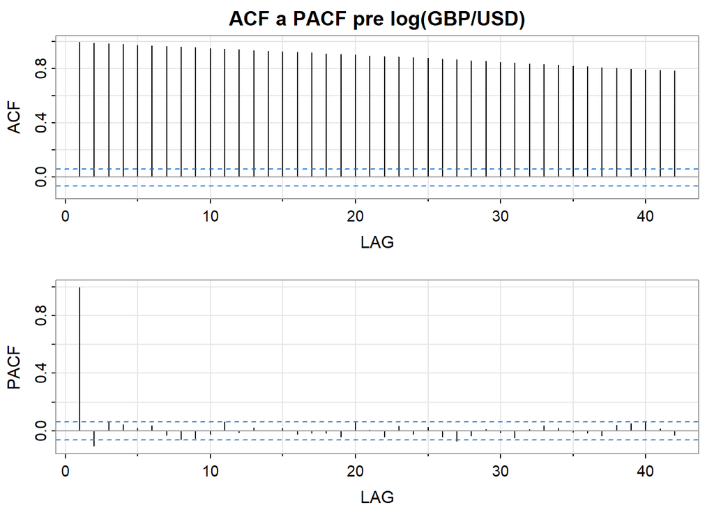

```
##      [,1]  [,2] [,3] [,4] [,5] [,6]  [,7]  [,8]  [,9] [,10] [,11] [,12] [,13]
## ACF     1  0.99 0.98 0.98 0.97 0.97  0.97  0.96  0.96  0.95  0.94  0.94  0.94
## PACF    1 -0.10 0.06 0.04 0.02 0.04 -0.03 -0.06 -0.05 -0.02  0.06 -0.01  0.02
##      [,14] [,15] [,16] [,17] [,18] [,19] [,20] [,21] [,22] [,23] [,24] [,25]
## ACF   0.93  0.93  0.92  0.92  0.91  0.91  0.90  0.90  0.89  0.89  0.88  0.88
## PACF  0.00  0.02 -0.02 -0.01 -0.01 -0.04  0.07  0.01 -0.04  0.03 -0.02  0.03
##      [,26] [,27] [,28] [,29] [,30] [,31] [,32] [,33] [,34] [,35] [,36] [,37]
## ACF   0.87  0.87  0.86  0.86  0.85  0.84  0.84  0.83  0.83  0.82  0.81  0.81
## PACF -0.04 -0.07 -0.03  0.01 -0.01 -0.05  0.01  0.04  0.02 -0.01 -0.02 -0.03
##      [,38] [,39] [,40] [,41] [,42]
## ACF   0.80  0.80  0.79  0.79  0.79
## PACF  0.04  0.05  0.06  0.01 -0.03
```

```r
# ACF a PACF pre logaritmus GBP/USD
acf2(logkurzy$GBPUSD, main = "ACF a PACF pre log(GBP/USD)")
```

Na základe týchto výsledkov predpokladáme, že časové rady logaritmov kurzov sú **integrovaného rádu I(1)**. Preto budeme ďalej pracovať s ich **prvými diferenciami**, teda **spojitými výnosmi**.

```r
# Výpočet denných spojitých výnosov (1. diferencie log-kurzov)
logreturns <- na.omit(diff(logkurzy))
```

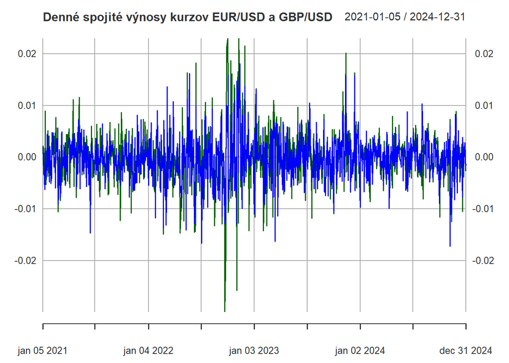

```r
# Grafické znázornenie spojitých výnosov
plot(logreturns, main = "Denné spojité výnosy kurzov EUR/USD a GBP/USD",
     col = c("blue", "darkgreen"), lwd = 1.5)
```

Graf zobrazuje **spojité výnosy** (prvé diferencie prirodzených logaritmov) kurzov EUR/USD(modrá čiara) a GBP/USD(zelená čiara) v období od januára 2021 do decembra 2024.

Na rozdiel od pôvodných kurzov,tieto výnosy sa pohybujú **okolo nulovej hodnoty**, čo je typické správanie **stacionárneho časového radu**. Zároveň je vidieť, že rozptyl výnosov nie je konštantný, čo naznačuje **kolísavosť volatility** v čase – potenciálnu prítomnosť heteroskedasticity.

# 3 3. Výber ARMA modelov pre spojité výnosy

Na výber vhodných ARMA modelov pre denné výnosy výmenných kurzov EUR/USD a GBP/USD bola použitá funkcia `auto.arima()`, ktorá na základe informačných kritérií (AIC, prípadne BIC) automaticky určí najvhodnejšie kombinácie parametrov AR (autoregresia) a MA (klzavý priemer).

```r
# Automatický výber ARMA modelu pre EUR/USD výnosy
auto_arma_eur <- auto.arima(logreturns$EURUSD, seasonal = FALSE, ic = "aic")
summary(auto_arma_eur)
```

```
## Series: logreturns$EURUSD
## ARIMA(0,0,1) with zero mean
##
## Coefficients:
##          ma1
##       0.0753
## s.e.  0.0312
##
## sigma^2 = 1.841e-05:  log likelihood = 4008.72
## AIC=-8013.43   AICc=-8013.42   BIC=-8003.63
##
## Training set error measures:
##                         ME        RMSE         MAE MPE MAPE      MASE
## Training set -0.0001568711 0.004288338 0.003171283 NaN  Inf 0.7309132
##                       ACF1
## Training set -0.0004617966
```

```r
# Manuálny výber pre EUR/USD
arma01_eur <- Arima(logreturns$EURUSD, order = c(0, 0, 1))
arma10_eur <- Arima(logreturns$EURUSD, order = c(1, 0, 0))
arma11_eur <- Arima(logreturns$EURUSD, order = c(1, 0, 1))
arma21_eur <- Arima(logreturns$EURUSD, order = c(2, 0, 1))

# Porovnanie podľa AIC
AIC(arma01_eur, arma10_eur, arma11_eur, arma21_eur)
```

```
##            df       AIC
## arma01_eur  3 -8012.765
## arma10_eur  3 -8012.800
## arma11_eur  4 -8010.804
## arma21_eur  5 -8008.807
```

### 3.0.1 EUR/USD:

Pre výnosy EUR/USD bol vybraný pomocou automatu model **ARMA(0,1) bez konštanty**, čo znamená, že proces je modelovaný pomocou jedného koeficientu klzavého priemeru (MA). MA(1) koeficient je:

- **ma1 = 0.0753**

AIC modelu: **–8013.43**

Pre EUR/USD sme vyskúšali štyri modely: **ARMA(0,1)**, **ARMA(1,0)**, **ARMA(1,1)** a **ARMA(2,1)**. Najnižšiu hodnotu AIC dosiahol model ARMA(1,0). **Automaticky vybraný model ARMA(0,1) bez konštanty** má ešte nižšie AIC (**–8013.43**) a teda ho možno považovať za najvhodnejší.

```r
# Automatický výber ARMA modelu pre GBP/USD výnosy
auto_arma_gbp <- auto.arima(logreturns$GBPUSD, seasonal = FALSE, ic = "aic")
summary(auto_arma_gbp)
```

```
## Series: logreturns$GBPUSD
## ARIMA(2,0,3) with zero mean
##
## Coefficients:
##          ar1      ar2      ma1     ma2     ma3
##       1.4662  -0.9330  -1.3590  0.7275  0.1221
## s.e.  0.0444   0.0427   0.0536  0.0690  0.0329
##
## sigma^2 = 2.479e-05:  log likelihood = 3862.73
## AIC=-7713.45   AICc=-7713.37   BIC=-7684.04
##
## Training set error measures:
##                         ME        RMSE         MAE MPE MAPE      MASE
## Training set -7.737456e-05 0.004966179 0.003597689 NaN  Inf 0.7318995
##                      ACF1
## Training set -0.001282547
```

```r
# Manuálny výber pre GBP/USD
arma11_gbp <- Arima(logreturns$GBPUSD, order = c(1, 0, 1))
arma22_gbp <- Arima(logreturns$GBPUSD, order = c(2, 0, 2))
arma23_gbp <- Arima(logreturns$GBPUSD, order = c(2, 0, 3))
arma33_gbp <- Arima(logreturns$GBPUSD, order = c(3, 0, 3))

# Porovnanie podľa AIC
AIC(arma11_gbp, arma22_gbp, arma23_gbp, arma33_gbp)
```

```
##            df       AIC
## arma11_gbp  4 -7700.357
## arma22_gbp  6 -7704.964
## arma23_gbp  7 -7711.684
## arma33_gbp  8 -7705.011
```

### 3.0.2 GBP/USD:

Pre výnosy GBP/USD bol automatom vybraný model **ARMA(2,3) bez konštanty**, ktorý zahŕňa dva AR a tri MA koeficienty. Významné parametre:

- **ar1 = 1.4662**, **ar2 = –0.9330**
- **ma1 = –1.3590**, **ma2 = 0.7275**, **ma3 = 0.1221**

AIC modelu: **–7713.45**

Pre výnosy GBP/USD:sme vyskúšali štyri modely: **ARMA(1,1)**, **ARMA(2,2)**, **ARMA(2,3)** a **ARMA(3,3)**. Najnižšiu hodnotu AIC dosiahol model **ARMA(2,3) s nulovou strednou** a preto bol vybraný ako najvhodnejší spomedzi porovnávaných modelov.

### 3.0.3 Overenie stacionarity a invertovateľnosti

Aby bolo možné považovať ARMA model za stacionárny a invertovateľný, musia **korene charakteristických rovníc** AR a MA časti ležať **mimo jednotkového kruhu** (t. j. ich absolútna hodnota musí byť väčšia ako 1).

### 3.0.4 EUR/USD – ARMA(0,1)

```r
# Model bez konštanty (ako z auto.arima)
arma01_eur <- Arima(logreturns$EURUSD, order = c(0, 0, 1), include.mean = FALSE)

# MA(1) – inverznosť
ma1_coef <- arma01_eur$coef["ma1"]
ma_roots <- polyroot(c(1, ma1_coef))
abs(ma_roots)        # absolútne hodnoty koreňov
```

```
## [1] 13.27293
```

```r
1/ma_roots           # inverzné korene patria do jednotkového kruhu
```

```
## [1] -0.07534129+0i
```

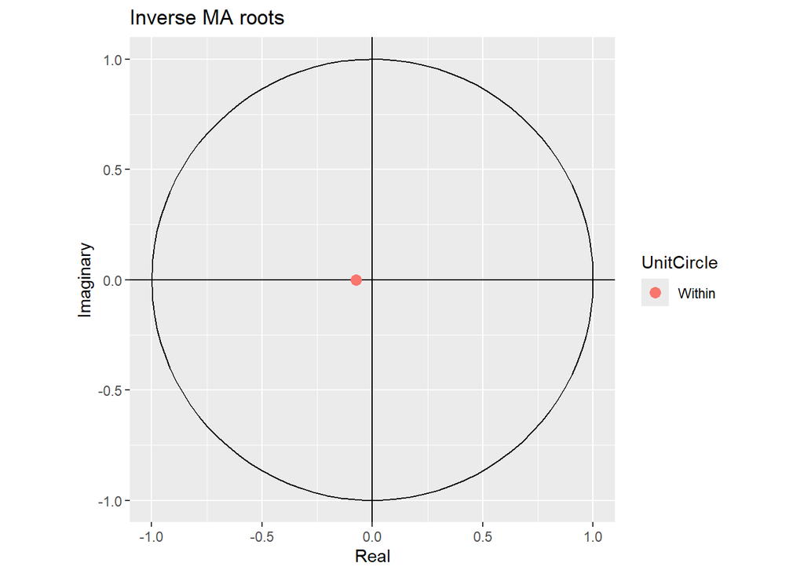

```r
# Pre EUR/USD model ARMA(0,1)
arma_eur <- Arima(logreturns$EURUSD, order = c(0, 0, 1), include.mean = FALSE)
autoplot(arma_eur)
```

Model obsahuje iba MA(1) zložku. Výpočet ukázal, že **absolútna hodnota koreňa MA časti je väčšia ako 1**, čo znamená, že model je **invertovateľný**.

### 3.0.5 GBP/USD – ARMA(2,3)

```r
arma23_gbp <- Arima(logreturns$GBPUSD, order = c(2, 0, 3), include.mean = FALSE)

# AR(2) – stacionarita
ar1 <- arma23_gbp$coef["ar1"]
ar2 <- arma23_gbp$coef["ar2"]
ar_roots <- polyroot(c(1, -ar1, -ar2))
abs(ar_roots)        # absolútne hodnoty koreňov
```

```
## [1] 1.03526 1.03526
```

```r
1/ar_roots           # inverzné korene (AR časť)patria do jednotkového kruhu
```

```
## [1] 0.7331074-0.6289632i 0.7331074+0.6289632i
```

```r
# MA(3) – invertovateľnosť
ma1 <- arma23_gbp$coef["ma1"]
ma2 <- arma23_gbp$coef["ma2"]
ma3 <- arma23_gbp$coef["ma3"]
ma_roots <- polyroot(c(1, ma1, ma2, ma3))
abs(ma_roots)        # absolútne hodnoty koreňov
```

```
## [1] 1.040030 1.040030 7.569723
```

```r
1/ma_roots           # inverzné korene (MA časť) patria do jednotkového kruhu
```

```
## [1]  0.7455494-6.071726e-01i  0.7455494+6.071726e-01i -0.1321052+1.983043e-18i
```

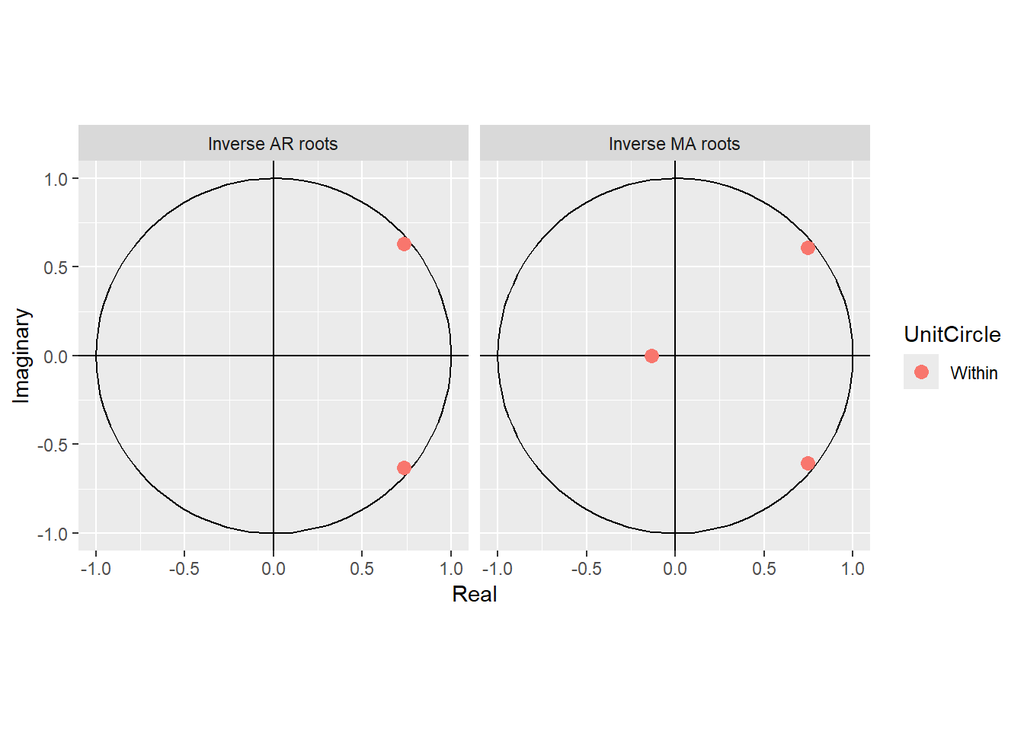

```r
autoplot(arma23_gbp)
```

Model obsahuje dve AR a tri MA zložky. Výpočet ukázal, že absolútne hodnoty všetkých koreňov AR časti sú väčšie ako 1, čo znamená, že model je **stacionárny** . Rovnako aj všetky korene MA časti ležia mimo jednotkového kruhu, čím je splnená podmienka **invertovateľnosti** .

## 3.1 Diagnostika rezíduí ARIMA modelov

```r
# Reziduá a ich štvorce
res_eur <- residuals(arma01_eur)
res2_eur <- res_eur^2

res_gbp <- residuals(arma23_gbp)
res2_gbp <- res_gbp^2
```

```r
# Veľkosť výberu a maximálny počet lagov (T/4)
T <- length(res_eur)
max_lag <- floor(T / 4)
max_lag
```

```
## [1] 248
```

```r
# Počet parametrov (fitdf)
fitdf_eur <- 1  # ARMA(0,1)
fitdf_gbp <- 5  # ARMA(2,3)
```

## 3.2 Ljung-Box test na rezíduá

Na testovanie správnosti špecifikácie ARIMA(0,0,1) a ARIMA(2,0,3) modelu pre výnosy EUR/USD a GBP/USD sme aplikovali Ljung-Boxov test na:

1. **Rezíduá** – testuje, či sú nekorelované (t. j. či model dostatočne vysvetľuje dynamiku).
2. **Štvorce rezíduí** – testuje, či je prítomný **ARCH efekt** (nestálosť rozptylu).

Testovanie bolo vykonané pre oneskorenia od **3 do 248**, pričom sme zvolili počet parametrov pre model ARIMA(0,0,1) jeden parameter `fitdf = 1` a pre model ARIMA(2,0,3) päť parameterov `fitdf = 5`

```r
#EUR/USD
#ARIMA(0,0,1)

stat <- c()
p_value <- c()
df <- c()

stat2 <- c()
p_value2 <- c()
df2 <- c()

for (x in 3:max_lag) {
  #reziduá
  test <- Box.test(res_eur, lag = x, type = "Ljung-Box", fitdf = fitdf_eur)
  stat[x] <- test$statistic
  p_value[x] <- test$p.value
  df[x] <- test$parameter

  #štvorce reziduí
  test2 <- Box.test(res2_eur, lag = x, type = "Ljung-Box", fitdf = fitdf_eur)
  stat2[x] <- test2$statistic
  p_value2[x] <- test2$p.value
  df2[x] <- test2$parameter
}

# Tabuľka výsledkov pre rezíduá
ljung_eur_resid <- cbind(Lag = 3:max_lag, Statistic = stat[3:max_lag], P_value = p_value[3:max_lag], DF = df[3:max_lag])
ljung_eur_resid2 <- cbind(Lag = 3:max_lag, Stat = stat2[3:max_lag], P = p_value2[3:max_lag])
#ljung_eur_resid
#ljung_eur_resid2
```

```r
# Jarque-Bera test na normálnosť rezíduí
jarque.bera.test(res_eur)
```

```
##
##  Jarque Bera Test
##
## data:  res_eur
## X-squared = 145.05, df = 2, p-value < 2.2e-16
```

```r
# ARCH LM test – testovanie prítomnosti ARCH efektu
ArchTest(res_eur, lags = 1)
```

```
##
##  ARCH LM-test; Null hypothesis: no ARCH effects
##
## data:  res_eur
## Chi-squared = 16.846, df = 1, p-value = 4.053e-05
```

### 3.2.1 Diagnostika rezíduí modelu ARMA(0,1) – EUR/USD

#### 3.2.1.1 Ljung-Box test na rezíduá

Ljung-Box test bol aplikovaný na rezíduá z modelu ARMA(0,1) s cieľom overiť ich nekorelovanosť. Výsledky ukazujú, že:

- Pre lagy 3 až 248 sú **p-hodnoty väčšinou vyššie ako 0.05**, čo znamená, že **nulová hypotéza o nekorelovanosti sa nezamieta**.
- Teda môžeme **považovať rezíduá za nekorelované**.

#### 3.2.1.2 Ljung-Box test na štvorce rezíduí

Na štvorce rezíduí bol aplikovaný rovnaký test s cieľom zistiť prítomnosť **ARCH efektu**:

- Už od najnižších lagov (lag 3 a ďalej) sú **p-hodnoty veľmi nízke (<< 0.01)** a rýchlo klesajú až k hodnote 0.000000.
- Výsledok indikuje **prítomnosť ARCH efektu**.

#### 3.2.1.3 Jarque-Bera test – normalita rezíduí

Výsledok testu:

- JB štatistika = 145.05
- p-hodnota < 2.2e-16

→ **Zamietame nulovú hypotézu o normalite rozdelenia rezíduí.**  
Rezíduá modelu ARMA(0,1) pre výnosy EUR/USD nemajú normálne rozdelenie.

#### 3.2.1.4 ARCH LM test – homoskedasticita

Výsledok testu:

- Chi-squared = 16.846
- p-hodnota = 4.053e-05

→ **Zamietame nulovú hypotézu o neprítomnosti ARCH efektu.**  
To znamená, že v reziduách je **prítomný ARCH efekt**, teda rozptyl nie je konštantný, ale sa mení v čase.

#### 3.2.1.5 Záver

Pre model ARMA(0,1) na výnosy EUR/USD: - Rezíduá **nie sú korelované** - Rezíduá **nie sú normálne rozdelené** - Výrazne sa prejavuje **ARCH efekt**

```r
#GBP/USD
#ARIMA(2,0,3)

stat <- c()
p_value <- c()
df <- c()

stat2 <- c()
p_value2 <- c()
df2 <- c()

for (x in 6:max_lag) {
  #reziduá
  test <- Box.test(res_gbp, lag = x, type = "Ljung-Box", fitdf = fitdf_gbp)
  stat[x] <- test$statistic
  p_value[x] <- test$p.value
  df[x] <- test$parameter

  #štvorce reziduí
  test2 <- Box.test(res2_gbp, lag = x, type = "Ljung-Box", fitdf = fitdf_gbp)
  stat2[x] <- test2$statistic
  p_value2[x] <- test2$p.value
  df2[x] <- test2$parameter
}

# Tabuľka výsledkov pre rezíduá
ljung_gbp_resid <- cbind(Lag = 6:max_lag, Statistic = stat[6:max_lag], P_value = p_value[6:max_lag], DF = df[6:max_lag])
ljung_gbp_resid2 <- cbind(Lag = 6:max_lag, Statistic = stat2[6:max_lag], P_value = p_value2[6:max_lag], DF = df2[6:max_lag])
#ljung_gbp_resid
#ljung_gbp_resid2
```

```r
# Jarque-Bera test na normálnosť rezíduí
jarque.bera.test(res_gbp)
```

```
##
##  Jarque Bera Test
##
## data:  res_gbp
## X-squared = 557.29, df = 2, p-value < 2.2e-16
```

```r
# ARCH LM test – testovanie prítomnosti ARCH efektu
ArchTest(res_gbp, lags = 1)
```

```
##
##  ARCH LM-test; Null hypothesis: no ARCH effects
##
## data:  res_gbp
## Chi-squared = 41.652, df = 1, p-value = 1.09e-10
```

### 3.2.2 Diagnostika rezíduí modelu ARMA(2,3) – GBP/USD

#### 3.2.2.1 Ljung-Box test na rezíduá

Ljung-Box test bol aplikovaný na rezíduá z modelu ARMA(2,3) pre výnosy GBP/USD. Výsledky ukazujú, že:

- Pre lagy od 6 do 248 sú **p-hodnoty jednoznačne vyššie ako 0.05**, čo znamená, že **rezíduá sú nekorelované**.

#### 3.2.2.2 Ljung-Box test na štvorce rezíduí

Testovanie bolo následne aplikované na štvorce rezíduí za účelom detekcie **ARCH efektu**:

- Výsledky ukazujú, že už od lagov 6 až po 248 sú **p-hodnoty nulové** .
- Znamená to silnú prítomnosť **heteroskedasticity v reziduách** – **ARCH efekt**.

#### 3.2.2.3 Jarque-Bera test – normalita rezíduí

Výsledok testu:

- JB štatistika = 557.29
- p-hodnota < 2.2e-16

→ **Zamietame nulovú hypotézu o normalite rozdelenia rezíduí.**  
Rezíduá modelu ARMA(2,3) pre výnosy GBP/USD **nemajú normálne rozdelenie**, čo je v súlade s očakávaniami pre finančné časové rady.

#### 3.2.2.4 ARCH LM test – homoskedasticita

Výsledok testu:

- Chi-squared = 41.652
- p-hodnota = 1.09e-10

→ **Zamietame nulovú hypotézu o neprítomnosti ARCH efektu.**  
V reziduách je výrazne prítomný **ARCH efekt**.

#### 3.2.2.5 Záver

Pre model ARMA(2,3) na výnosy GBP/USD platí:

- Rezíduá **nie sú korelované**
- Rezíduá **nie sú normálne rozdelené**
- ARCH efekt je **výrazne prítomný**

# 4 4. Odhad modelov GARCH(1,1), EGARCH(1,1), GJR(1,1)

Pre výnosy EUR/USD a GBP/USD boli odhadnuté tri modely triedy ARCH: **GARCH(1,1), EGARCH(1,1), GJR(1,1)**.

## 4.1 EUR/USD – model ARMA(0,1) + GARCH typy

```r
# GARCH(1,1) modelu pre EUR/USD
spec_garch_eur <- ugarchspec(
  variance.model = list(model = "sGARCH", garchOrder = c(1,1)),  #  GARCH(1,1)
  mean.model = list(armaOrder = c(0,1), include.mean = FALSE)  # ARMA(0,1) bez konstanty
)
fit_garch_eur <- ugarchfit(spec = spec_garch_eur, data = logreturns$EURUSD)
fit_garch_eur
```

```
##
## *---------------------------------*
## *          GARCH Model Fit        *
## *---------------------------------*
##
## Conditional Variance Dynamics
## -----------------------------------
## GARCH Model  : sGARCH(1,1)
## Mean Model   : ARFIMA(0,0,1)
## Distribution : norm
##
## Optimal Parameters
## ------------------------------------
##         Estimate  Std. Error  t value Pr(>|t|)
## ma1     0.056797    0.032647  1.73970 0.081911
## omega   0.000000    0.000001  0.17461 0.861385
## alpha1  0.032875    0.016193  2.03021 0.042335
## beta1   0.958238    0.016286 58.83800 0.000000
##
## Robust Standard Errors:
##         Estimate  Std. Error  t value Pr(>|t|)
## ma1     0.056797    0.047702 1.190654  0.23379
## omega   0.000000    0.000050 0.003392  0.99729
## alpha1  0.032875    0.759706 0.043273  0.96548
## beta1   0.958238    0.776202 1.234521  0.21701
##
## LogLikelihood : 4049.746
##
## Information Criteria
## ------------------------------------
##
## Akaike       -8.1403
## Bayes        -8.1206
## Shibata      -8.1404
## Hannan-Quinn -8.1328
##
## Weighted Ljung-Box Test on Standardized Residuals
## ------------------------------------
##                         statistic p-value
## Lag[1]                  0.0003157  0.9858
```

[output cut: 37 more lines]

```
## Negative Sign Bias  0.2534 0.8000
## Positive Sign Bias  0.4046 0.6859
## Joint Effect        0.6333 0.8888
##
##
## Adjusted Pearson Goodness-of-Fit Test:
## ------------------------------------
##   group statistic p-value(g-1)
## 1    20     27.81      0.08714
## 2    30     35.48      0.18931
## 3    40     46.80      0.18268
## 4    50     50.57      0.41142
##
##
## Elapsed time : 0.09264493
```

```r
fit_garch_eur@fit$persistence
```

```
## [1] 0.9911129
```

### 4.1.1 GARCH(1,1)

```r
# EGARCH(1,1) modelu pre EUR/USD
spec_egarch_eur <- ugarchspec(
  variance.model = list(model = "eGARCH", garchOrder = c(1,1)),  # exponenciálny GARCH
  mean.model = list(armaOrder = c(0,1), include.mean = FALSE)
)
fit_egarch_eur <- ugarchfit(spec = spec_egarch_eur, data = logreturns$EURUSD)
fit_egarch_eur
```

```
##
## *---------------------------------*
## *          GARCH Model Fit        *
## *---------------------------------*
##
## Conditional Variance Dynamics
## -----------------------------------
## GARCH Model  : eGARCH(1,1)
## Mean Model   : ARFIMA(0,0,1)
## Distribution : norm
##
## Optimal Parameters
## ------------------------------------
##         Estimate  Std. Error    t value Pr(>|t|)
## ma1     0.050516    0.031821     1.5875 0.112394
## omega  -0.078100    0.001269   -61.5266 0.000000
## alpha1 -0.024333    0.011957    -2.0349 0.041857
## beta1   0.992728    0.000026 38803.9083 0.000000
## gamma1  0.061756    0.001149    53.7674 0.000000
##
## Robust Standard Errors:
##         Estimate  Std. Error    t value Pr(>|t|)
## ma1     0.050516    0.033005     1.5305 0.125885
## omega  -0.078100    0.002192   -35.6303 0.000000
## alpha1 -0.024333    0.013826    -1.7599 0.078428
## beta1   0.992728    0.000033 30481.6578 0.000000
## gamma1  0.061756    0.001228    50.3074 0.000000
##
## LogLikelihood : 4053.121
##
## Information Criteria
## ------------------------------------
##
## Akaike       -8.1451
## Bayes        -8.1205
## Shibata      -8.1452
## Hannan-Quinn -8.1357
##
## Weighted Ljung-Box Test on Standardized Residuals
## ------------------------------------
```

[output cut: 40 more lines]

```
## Negative Sign Bias  0.3803 0.7038
## Positive Sign Bias  0.6478 0.5173
## Joint Effect        1.3788 0.7105
##
##
## Adjusted Pearson Goodness-of-Fit Test:
## ------------------------------------
##   group statistic p-value(g-1)
## 1    20     27.93      0.08475
## 2    30     42.12      0.05482
## 3    40     47.05      0.17635
## 4    50     61.43      0.10951
##
##
## Elapsed time : 0.187638
```

```r
fit_egarch_eur@fit$persistence
```

```
## [1] 0.9927282
```

### 4.1.2 EGARCH(1,1)

- **Perzistencia** ≈ **0.9927** → vysoká zotrvačnosť šokov
- **Asymetria**: gamma1 = 0.0618,štatisticky významný → asymetrický efekt je prítomný, ide o pákový efekt
- alpha1 = -0.0243, štatisticky významný → asymetria vo volatilite bola potvrdená
- beta1 = 0.9927 → vysoká zotrvačnosť vo volatilite
- **Ljung-Box testy** a **ARCH LM testy** ukazujú že rezíduá nie sú korelované a nebola potvrdená prítomnosťt ARCH efektu.
- AIC = **-8.1451**.

```r
# --- Špecifikácia a odhad GJR(1,1) modelu pre EUR/USD ---
spec_gjr_eur <- ugarchspec(
  variance.model = list(model = "gjrGARCH", garchOrder = c(1,1)),  # GJR model
  mean.model = list(armaOrder = c(0,1), include.mean = FALSE)
)
fit_gjr_eur <- ugarchfit(spec = spec_gjr_eur, data = logreturns$EURUSD)
fit_gjr_eur
```

```
##
## *---------------------------------*
## *          GARCH Model Fit        *
## *---------------------------------*
##
## Conditional Variance Dynamics
## -----------------------------------
## GARCH Model  : gjrGARCH(1,1)
## Mean Model   : ARFIMA(0,0,1)
## Distribution : norm
##
## Optimal Parameters
## ------------------------------------
##         Estimate  Std. Error  t value Pr(>|t|)
## ma1     0.061835    0.032073   1.9279 0.053862
## omega   0.000000    0.000000   0.3262 0.744273
## alpha1  0.007670    0.005394   1.4219 0.155053
## beta1   0.973417    0.003004 323.9946 0.000000
## gamma1  0.028463    0.012454   2.2855 0.022283
##
## Robust Standard Errors:
##         Estimate  Std. Error   t value Pr(>|t|)
## ma1     0.061835    0.034541  1.790210  0.07342
## omega   0.000000    0.000005  0.015997  0.98724
## alpha1  0.007670    0.078927  0.097182  0.92258
## beta1   0.973417    0.060600 16.063061  0.00000
## gamma1  0.028463    0.032000  0.889486  0.37374
##
## LogLikelihood : 4050.688
##
## Information Criteria
## ------------------------------------
##
## Akaike       -8.1402
## Bayes        -8.1156
## Shibata      -8.1403
## Hannan-Quinn -8.1308
##
## Weighted Ljung-Box Test on Standardized Residuals
## ------------------------------------
```

[output cut: 40 more lines]

```
## Negative Sign Bias  0.1611 0.8720
## Positive Sign Bias  0.7621 0.4462
## Joint Effect        1.2641 0.7377
##
##
## Adjusted Pearson Goodness-of-Fit Test:
## ------------------------------------
##   group statistic p-value(g-1)
## 1    20     31.39      0.03654
## 2    30     42.12      0.05482
## 3    40     57.51      0.02829
## 4    50     53.89      0.29286
##
##
## Elapsed time : 0.1930699
```

```r
fit_gjr_eur@fit$persistence
```

```
## [1] 0.9953188
```

### 4.1.3 GJR(1,1)

- **Perzistencia**: alpha1 + beta1 + 0.5*gamma1 ≈ 0.0077 + 0.9734 + 0.0142 = **0.9953** → vysoká zotrvačnosť šokov.
- alpha1 = 0.0077 → nie je štatisticky významný
- beta1 = 0.9734 → vysoká zotrvačnosť vo volatilite
- Asymetrický parameter gamma1 = 0.0285, ale v robustnom odhade **nie je štatisticky významný**.
- **Ljung-Box testy** a **ARCH LM testy** ukazujú že rezíduá nie sú korelované a nebola potvrdená prítomnosťt ARCH efektu.
- AIC = **–8.1402**.

## 4.2 GBP/USD – model ARMA(2,3) + GARCH typy

```r
# GARCH(1,1) pre GBP/USD
spec_garch_gbp <- ugarchspec(
  variance.model = list(model = "sGARCH", garchOrder = c(1,1)),
  mean.model = list(armaOrder = c(2,3), include.mean = FALSE),
  distribution.model = "norm"
)
fit_garch_gbp <- ugarchfit(spec = spec_garch_gbp, data = logreturns$GBPUSD)
fit_garch_gbp
```

```
##
## *---------------------------------*
## *          GARCH Model Fit        *
## *---------------------------------*
##
## Conditional Variance Dynamics
## -----------------------------------
## GARCH Model  : sGARCH(1,1)
## Mean Model   : ARFIMA(2,0,3)
## Distribution : norm
##
## Optimal Parameters
## ------------------------------------
##         Estimate  Std. Error  t value Pr(>|t|)
## ar1     1.409460    0.237827  5.92641 0.000000
## ar2    -0.750483    0.128325 -5.84832 0.000000
## ma1    -1.335551    0.239602 -5.57404 0.000000
## ma2     0.577323    0.143866  4.01293 0.000060
## ma3     0.123672    0.043941  2.81454 0.004885
## omega   0.000000    0.000001  0.32846 0.742565
## alpha1  0.039794    0.016747  2.37611 0.017496
## beta1   0.946491    0.017474 54.16511 0.000000
##
## Robust Standard Errors:
##         Estimate  Std. Error   t value Pr(>|t|)
## ar1     1.409460    2.284333  0.617012 0.537227
## ar2    -0.750483    1.096885 -0.684195 0.493852
## ma1    -1.335551    2.278361 -0.586189 0.557748
## ma2     0.577323    1.200147  0.481043 0.630486
## ma3     0.123672    0.395177  0.312954 0.754315
## omega   0.000000    0.000026  0.011864 0.990534
## alpha1  0.039794    0.405426  0.098153 0.921811
## beta1   0.946491    0.435173  2.174979 0.029632
##
## LogLikelihood : 3938.157
##
## Information Criteria
## ------------------------------------
##
## Akaike       -7.9078
```

[output cut: 49 more lines]

```
## Negative Sign Bias  0.5623 0.5740
## Positive Sign Bias  0.7810 0.4350
## Joint Effect        2.7240 0.4362
##
##
## Adjusted Pearson Goodness-of-Fit Test:
## ------------------------------------
##   group statistic p-value(g-1)
## 1    20     30.63     0.044333
## 2    30     54.43     0.002886
## 3    40     54.69     0.048889
## 4    50     68.88     0.032003
##
##
## Elapsed time : 0.193536
```

```r
fit_garch_gbp@fit$persistence
```

```
## [1] 0.9862851
```

### 4.2.1 GARCH(1,1)

- **Perzistencia = 0.9863**
- Všetky parametre okrem beta1 sú štatisticky nevýznamné podľa robustných odhadov.
- **Ljung-Box testy** a **ARCH LM testy** ukazujú že rezíduá nie sú korelované a nebola potvrdená prítomnosťt ARCH efektu.
- **AIC = -7.9078**

```r
# EGARCH(1,1) pre GBP/USD
spec_egarch_gbp <- ugarchspec(
  variance.model = list(model = "eGARCH", garchOrder = c(1,1)),
  mean.model = list(armaOrder = c(2,3), include.mean = FALSE),
  distribution.model = "norm"
)
fit_egarch_gbp <- ugarchfit(spec = spec_egarch_gbp, data = logreturns$GBPUSD)
fit_egarch_gbp
```

```
##
## *---------------------------------*
## *          GARCH Model Fit        *
## *---------------------------------*
##
## Conditional Variance Dynamics
## -----------------------------------
## GARCH Model  : eGARCH(1,1)
## Mean Model   : ARFIMA(2,0,3)
## Distribution : norm
##
## Optimal Parameters
## ------------------------------------
##         Estimate  Std. Error     t value Pr(>|t|)
## ar1     1.452374    0.064765  2.2425e+01        0
## ar2    -0.767943    0.033067 -2.3224e+01        0
## ma1    -1.381356    0.064919 -2.1278e+01        0
## ma2     0.602790    0.029640  2.0337e+01        0
## ma3     0.118466    0.015757  7.5184e+00        0
## omega  -0.048210    0.000833 -5.7855e+01        0
## alpha1 -0.054839    0.008164 -6.7170e+00        0
## beta1   0.995548    0.000001  1.0762e+06        0
## gamma1  0.033337    0.001161  2.8702e+01        0
##
## Robust Standard Errors:
##         Estimate  Std. Error     t value Pr(>|t|)
## ar1     1.452374    0.058937     24.6430  0.0e+00
## ar2    -0.767943    0.023083    -33.2682  0.0e+00
## ma1    -1.381356    0.057319    -24.0995  0.0e+00
## ma2     0.602790    0.015209     39.6339  0.0e+00
## ma3     0.118466    0.008621     13.7411  0.0e+00
## omega  -0.048210    0.001165    -41.3650  0.0e+00
## alpha1 -0.054839    0.013128     -4.1774  2.9e-05
## beta1   0.995548    0.000002 628463.5364  0.0e+00
## gamma1  0.033337    0.001492     22.3473  0.0e+00
##
## LogLikelihood : 3947.333
##
## Information Criteria
## ------------------------------------
```

[output cut: 52 more lines]

```
## Negative Sign Bias  0.3684 0.7126
## Positive Sign Bias  1.5098 0.1314
## Joint Effect        3.1298 0.3720
##
##
## Adjusted Pearson Goodness-of-Fit Test:
## ------------------------------------
##   group statistic p-value(g-1)
## 1    20     26.93      0.10640
## 2    30     46.34      0.02169
## 3    40     48.58      0.13996
## 4    50     48.96      0.47483
##
##
## Elapsed time : 0.438911
```

```r
fit_egarch_gbp@fit$persistence
```

```
## [1] 0.9955482
```

### 4.2.2 EGARCH(1,1)

- **Perzistencia** ≈ **0.9955** → vysoká zotrvačnosť šokov
- **Asymetria**: gamma1 = 0.0333,štatisticky významný → asymetrický efekt je prítomný, ide o pákový efekt
- alpha1 = -0.0548, štatisticky významný → asymetria vo volatilite bola potvrdená
- beta1 = 0.9955 → vysoká zotrvačnosť vo volatilite
- **Ljung-Box testy** a **ARCH LM testy** ukazujú že rezíduá nie sú korelované a nebola potvrdená prítomnosťt ARCH efektu.
- AIC = **-7.9242**.

```r
# GJR(1,1) pre GBP/USD
spec_gjr_gbp <- ugarchspec(
  variance.model = list(model = "gjrGARCH", garchOrder = c(1,1)),
  mean.model = list(armaOrder = c(2,3), include.mean = FALSE),
  distribution.model = "norm"
)
fit_gjr_gbp <- ugarchfit(spec = spec_gjr_gbp, data = logreturns$GBPUSD)
fit_gjr_gbp
```

```
##
## *---------------------------------*
## *          GARCH Model Fit        *
## *---------------------------------*
##
## Conditional Variance Dynamics
## -----------------------------------
## GARCH Model  : gjrGARCH(1,1)
## Mean Model   : ARFIMA(2,0,3)
## Distribution : norm
##
## Optimal Parameters
## ------------------------------------
##         Estimate  Std. Error   t value Pr(>|t|)
## ar1     1.449851    0.145035   9.99655 0.000000
## ar2    -0.774618    0.087043  -8.89925 0.000000
## ma1    -1.378555    0.146340  -9.42020 0.000000
## ma2     0.613127    0.097788   6.26998 0.000000
## ma3     0.112270    0.032986   3.40354 0.000665
## omega   0.000000    0.000000   0.59050 0.554855
## alpha1  0.001104    0.003115   0.35452 0.722951
## beta1   0.971698    0.003635 267.28324 0.000000
## gamma1  0.041282    0.010105   4.08518 0.000044
##
## Robust Standard Errors:
##         Estimate  Std. Error   t value Pr(>|t|)
## ar1     1.449851    0.255450  5.675682 0.000000
## ar2    -0.774618    0.104465 -7.415131 0.000000
## ma1    -1.378555    0.247567 -5.568420 0.000000
## ma2     0.613127    0.131940  4.647003 0.000003
## ma3     0.112270    0.064593  1.738125 0.082189
## omega   0.000000    0.000002  0.047642 0.962002
## alpha1  0.001104    0.067517  0.016355 0.986951
## beta1   0.971698    0.058950 16.483332 0.000000
## gamma1  0.041282    0.021632  1.908342 0.056347
##
## LogLikelihood : 3944.942
##
## Information Criteria
## ------------------------------------
```

[output cut: 52 more lines]

```
## Negative Sign Bias   0.218 0.8275
## Positive Sign Bias   1.248 0.2124
## Joint Effect         2.942 0.4006
##
##
## Adjusted Pearson Goodness-of-Fit Test:
## ------------------------------------
##   group statistic p-value(g-1)
## 1    20     29.42      0.05965
## 2    30     42.30      0.05279
## 3    40     57.43      0.02875
## 4    50     65.86      0.05423
##
##
## Elapsed time : 0.310266
```

```r
fit_gjr_gbp@fit$persistence
```

```
## [1] 0.9934429
```

### 4.2.3 GJR(1,1)

- **Perzistencia** ≈ **0.9934** → vysoká zotrvačnosť šokov
- beta1 = 0.9716 → vysoká zotrvačnosť vo volatilite
- alpha1 a gamma1 nie sú štatisticky významné
- **Ljung-Box testy** a **ARCH LM testy** ukazujú že rezíduá nie sú korelované a nebola potvrdená prítomnosťt ARCH efektu.
- AIC = **-7.9194**.

### 4.2.4 Výber najvhodnejšieho modelu pre GBP/USD:

Najvhodnejším modelom pre GBP/USD je **EGARCH(1,1)**: - má **najnižšie AIC** , - všetky parametre sú štatisticky významné (aj γ₁), - potvrdzuje **asymetrický efekt vo volatilite**.

## 4.3 Diagnostika štandardizovaných rezíduí modelu EGARCH(1,1)

Po odhade modelu EGARCH(1,1) boli vypočítané **štandardizované reziduá** (reziduá delené štandardnou odchýlkou) a ich **štvorce**, na ktoré boli aplikované nasledujúce testy:

- **Ljung-Box test** na reziduá a štvorce rezíduí – testuje nekorelovanosť ,
- **ARCH LM test** – testuje prítomnosť zvyškového ARCH efektu,
- **Jarque-Bera test** – testuje normalitu rozdelenia rezíduí.

### 4.3.1 Výsledky pre EUR/USD (EGARCH model):

```r
# Výpočet štandardizovaných rezíduí z EGARCH modelu pre EUR/USD
egarch_eur.st.res <- fit_egarch_eur@fit$residuals / fit_egarch_eur@fit$sigma
```

```r
# Inicializácia
max_lag <- max_lag
stat <- p_value <- df <- numeric()
stat_sq <- p_value_sq <- df_sq <- numeric()

# Testy na reziduá a ich štvorce
for (x in 3:max_lag) {
  test <- Box.test(egarch_eur.st.res, lag = x, type = "Ljung", fitdf = 1)
  stat[x] <- test$statistic
  p_value[x] <- test$p.value
  df[x] <- test$parameter

  test <- Box.test(egarch_eur.st.res^2, lag = x, type = "Ljung", fitdf = 1)
  stat_sq[x] <- test$statistic
  p_value_sq[x] <- test$p.value
  df_sq[x] <- test$parameter
}

# Výsledné tabuľky
ljung_eur_table <- cbind(Lag = 3:max_lag, Stat = stat[3:max_lag], P_value = p_value[3:max_lag])
ljung_eur_sq_table <- cbind(Lag = 3:max_lag, Stat = stat_sq[3:max_lag], P_value = p_value_sq[3:max_lag])

#ljung_eur_table
#ljung_eur_sq_table
```

```r
# --- ARCH LM test na zvyškovú heteroskedasticitu ---
ArchTest(egarch_eur.st.res, lags = 1)
```

```
##
##  ARCH LM-test; Null hypothesis: no ARCH effects
##
## data:  egarch_eur.st.res
## Chi-squared = 0.99747, df = 1, p-value = 0.3179
```

```r
# --- Jarque-Bera test na normalitu štandardizovaných rezíduí ---
jarque.bera.test(egarch_eur.st.res)
```

```
##
##  Jarque Bera Test
##
## data:  egarch_eur.st.res
## X-squared = 140.14, df = 2, p-value < 2.2e-16
```

- **Ljung-Box test na štandardizované reziduá:** nezamietame H₀, reziduá sú nekorelované,
- **Ljung-Box test na štvorce štandardizovaných rezíduí:** nie je prítomný zvyškový ARCH efekt,
- **ARCH LM test:** Chi² = 0.997, p = 0.318 → nezamietame H₀, žiadna zvyšková heteroskedasticit*,
- **Jarque-Bera test:** X² = 140.14, p < 2.2e-16 → zamietame H₀, reziduá nie sú normálne rozdelené.

### 4.3.2 Výsledky pre GBP/USD (EGARCH model):

```r
# Výpočet štandardizovaných rezíduí z EGARCH modelu pre GBP/USD
egarch.st.res <- fit_egarch_gbp@fit$residuals / fit_egarch_gbp@fit$sigma
```

```r
# --- Ljung-Box test na štandardizované reziduá ---
stat <- c()
p_value <- c()
df <- c()

# --- Ljung-Box test na štvorce štandardizovaných rezíduí ---
stat_sq <- c()
p_value_sq <- c()
df_sq <- c()


for (x in 6:max_lag) {
  test <- Box.test(egarch.st.res, lag = x, type = "Ljung", fitdf = 5)
  stat[x] <- test$statistic
  p_value[x] <- test$p.value
  df[x] <- test$parameter


  test <- Box.test(egarch.st.res^2, lag = x, type = "Ljung", fitdf = 5)
  stat_sq[x] <- test$statistic
  p_value_sq[x] <- test$p.value
  df_sq[x] <- test$parameter
}

ljung_res_table <- cbind(Lag = 6:50, Stat = stat[6:50], P_value = p_value[6:50], DF = df[6:50])
ljung_res_sq_table <- cbind(Lag = 6:100, Stat = stat_sq[6:100], P_value = p_value_sq[6:100], DF = df_sq[6:100])


#ljung_res_table
#ljung_res_sq_table
```

```r
# --- ARCH LM test na zvyškovú heteroskedasticitu ---
library(FinTS)
ArchTest(egarch.st.res, lags = 1)
```

```
##
##  ARCH LM-test; Null hypothesis: no ARCH effects
##
## data:  egarch.st.res
## Chi-squared = 0.6876, df = 1, p-value = 0.407
```

```r
# --- Jarque-Bera test na normalitu štandardizovaných rezíduí ---
library(tseries)
jarque.bera.test(egarch.st.res)
```

```
##
##  Jarque Bera Test
##
## data:  egarch.st.res
## X-squared = 98.447, df = 2, p-value < 2.2e-16
```

- **Ljung-Box test na štandardizované reziduá:** nezamietame H₀, reziduá sú nekorelované,
- **Ljung-Box test na štvorce štandardizovaných rezíduí:** nie je prítomný zvyškový ARCH efekt,
- **ARCH LM test:**
  - Chi² = 0.6876, p-value = 0.407 → **nezamietame H₀**, **žiadna zvyšková heteroskedasticita**,
- **Jarque-Bera test:**
  - X² = 98.447, p-value < 2.2e-16 → **zamietame H₀**, **reziduá nie sú normálne rozdelené**.

# 5 5. Jednodňová predikcia (statická prognóza)

Na základe predchádzajúcej analýzy boli pre obidva menové páry ako najvhodnejšie modely zvolené **EGARCH(1,1)** modely.

```r
# --- Jednodňová predikcia pre EUR/USD ---
forecast_eur <- ugarchforecast(fit_egarch_eur, n.ahead = 1)
forecast_eur
```

```
##
## *------------------------------------*
## *       GARCH Model Forecast         *
## *------------------------------------*
## Model: eGARCH
## Horizon: 1
## Roll Steps: 0
## Out of Sample: 0
##
## 0-roll forecast [T0=2024-12-31]:
##         Series    Sigma
## T+1 -0.0001126 0.004288
```

##### 5.0.0.0.1 EUR/USD

- **Predikovaný výnos (logaritmický):** –0.0001126
- **Predikovaná volatilita (σ):** 0.004288

```r
# --- Jednodňová predikcia pre GBP/USD ---
forecast_gbp <- ugarchforecast(fit_egarch_gbp, n.ahead = 1)
forecast_gbp
```

```
##
## *------------------------------------*
## *       GARCH Model Forecast         *
## *------------------------------------*
## Model: eGARCH
## Horizon: 1
## Roll Steps: 0
## Out of Sample: 0
##
## 0-roll forecast [T0=2024-12-31]:
##         Series    Sigma
## T+1 -0.0002219 0.004591
```

```r
forecast_gbp@forecast$seriesFor
```

```
##        2024-12-31
## T+1 -0.0002219163
```

##### 5.0.0.0.2 GBP/USD

- **Predikovaný výnos (logaritmický):** –0.0002219
- **Predikovaná volatilita (σ):** 0.004591

# 6 6. Prieŕezová štandardná odchýlka

Na preskúmanie spoločného vývoja výnosov menových párov **EUR/USD** a **GBP/USD** boli využité nasledujúce štatistiky:

## 6.1 Nepodmienený korelačný koeficient

```r
correlation <- cor(logreturns$EURUSD, logreturns$GBPUSD)
correlation
```

```
##           GBPUSD
## EURUSD 0.7579562
```

Hodnota korelačného koeficienta **0.758** naznačuje, že ak sa zvýši výnos jedného menového páru, s veľkou pravdepodobnosťou sa zvýši aj výnos druhého. To potvrdzuje, že **menové páry sú navzájom silno prepojené** a majú podobný vývoj v čase.

```r
# Prierezová štandardná odchýlka pre každý deň
cross_sd <- apply(logreturns, 1, sd)

# Základné štatistiky o prierezovej štandardnej odchýlke
summary(cross_sd)
```

```
##      Min.   1st Qu.    Median      Mean   3rd Qu.      Max.
## 1.569e-06 6.164e-04 1.235e-03 1.702e-03 2.254e-03 1.360e-02
```

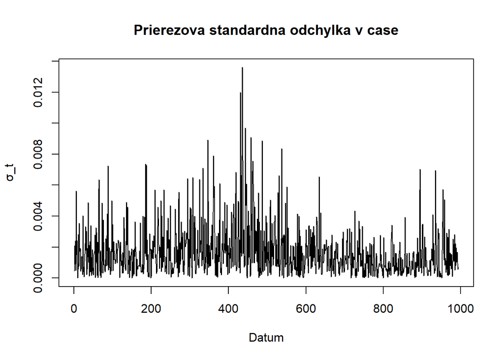

```r
#graf prieŕezovej štandardnej odchýlky
plot(cross_sd, type = "l", main = "Prierezova standardna odchylka v case", ylab = "σ_t", xlab = "Datum")
```

- **Minimum (0.0000016)**: značí veľmi podobné výnosy v daný deň. - **Maximum (0.0136)**: poukazuje na deň s výrazne odlišnými výnosmi medzi EUR/USD a GBP/USD. - **Medián (0.0012)** a **priemer (0.0017)** naznačujú, že priemerný rozdiel medzi oboma výnosmi bol pomerne malý.

Z grafu prieŕezovej štandardnej odchýlky vidíme, že: - v čase okolo 400–450 dní nastáva výrazný výkyv (pravdepodobne spojený s volatilným obdobím na trhu), - následne sa rozdiely medzi výnosmi stabilizujú.